# Tugas Pertemuan 5

# INPUT DATA

```r
data <- read_xlsx("C:\\Users\\ailed\\Downloads\\JKSE_Close_Weekly.xlsx")

data1 <- data[776:1033, ]
data1
```

```
## # A tibble: 258 × 2
##    Date                Close
##    <dttm>              <dbl>
##  1 2020-08-24 00:00:00 5347.
##  2 2020-08-31 00:00:00 5240.
##  3 2020-09-07 00:00:00 5017.
##  4 2020-09-14 00:00:00 5059.
##  5 2020-09-21 00:00:00 4946.
##  6 2020-09-28 00:00:00 4927.
##  7 2020-10-05 00:00:00 5054.
##  8 2020-10-12 00:00:00 5103.
##  9 2020-10-19 00:00:00 5112.
## 10 2020-10-26 00:00:00 5128.
## # ℹ 248 more rows
```

# SPLIT DATA

## Data Training

```r
# Data Training
dtgab1 <- data1[1:206, ]
ts_train <- ts(dtgab1$Close)
mean(ts_train)
```

```
## [1] 6648.181
```

```r
var(ts_train)
```

```
## [1] 317463.9
```

### Plot Time Series

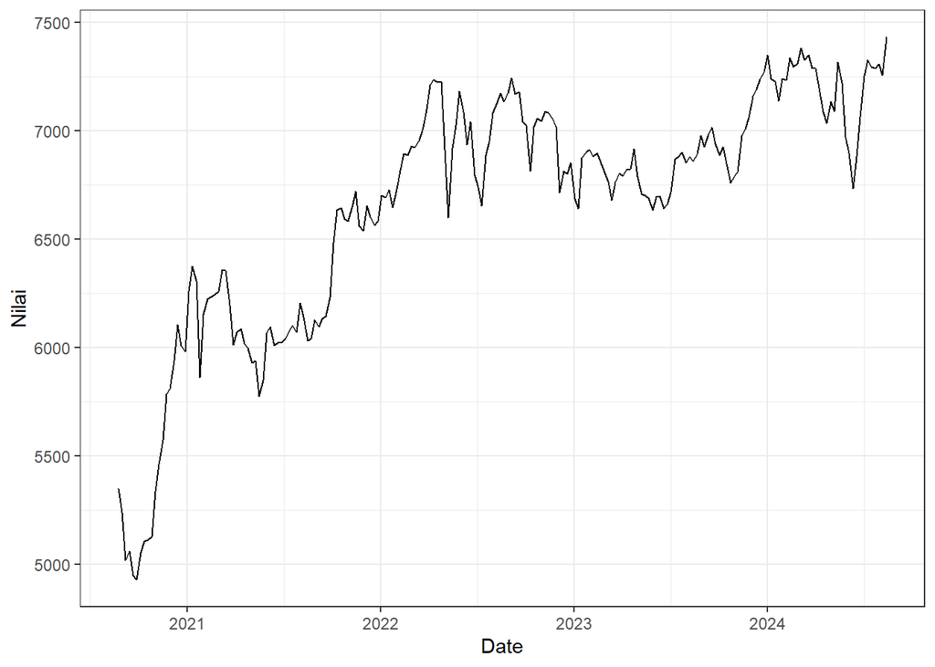

```r
plot2 <- ggplot(dtgab1, aes(x = Date, y = Close)) +
  geom_line() +
  theme_bw() +
  xlab("Date") +
  ylab("Nilai")

plot2
```

### Plot ACF

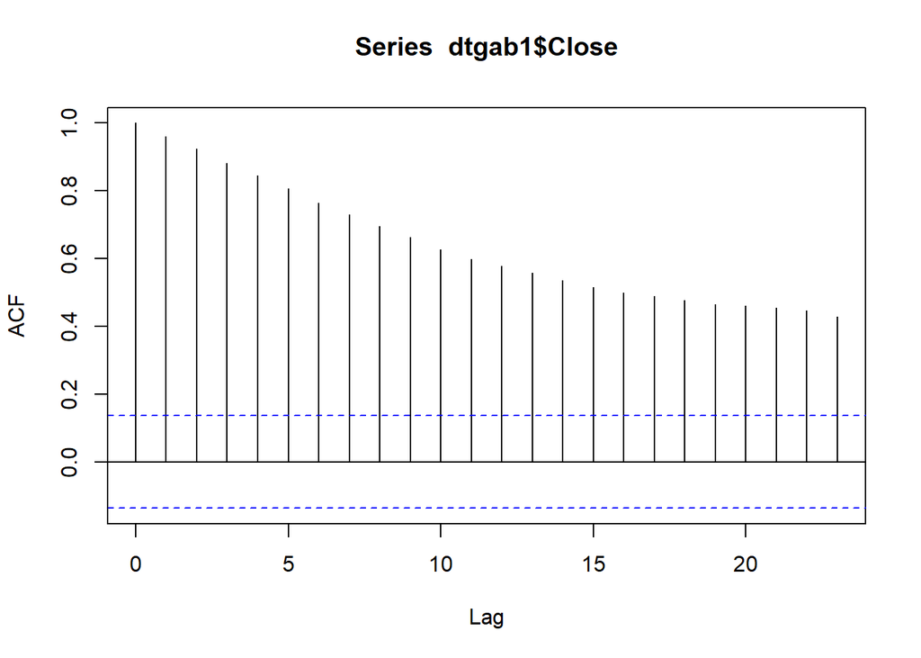

```r
acf(dtgab1$Close)
```

Berdasarkan plot ACF, terlihat bahwa plot ACF pada data training menurun secara perlahan (tails off slowly) pada banyak lag yang mengindikasikan kuat bahwa data **tidak stasioner dalam rataan**.

### Uji ADF

H0 : Data tidak stasioner dalam rataan

H1 : Data stasioner dalam rataan

```r
adf.test(dtgab1$Close)
```

```
##
##  Augmented Dickey-Fuller Test
##
## data:  dtgab1$Close
## Dickey-Fuller = -3.6918, Lag order = 5, p-value = 0.02596
## alternative hypothesis: stationary
```

### Plot Box-Cox

```r
index <- seq(1:206)
bc = boxcox(dtgab1$Close+1~index,
             lambda = seq(3,5,by=1))
```

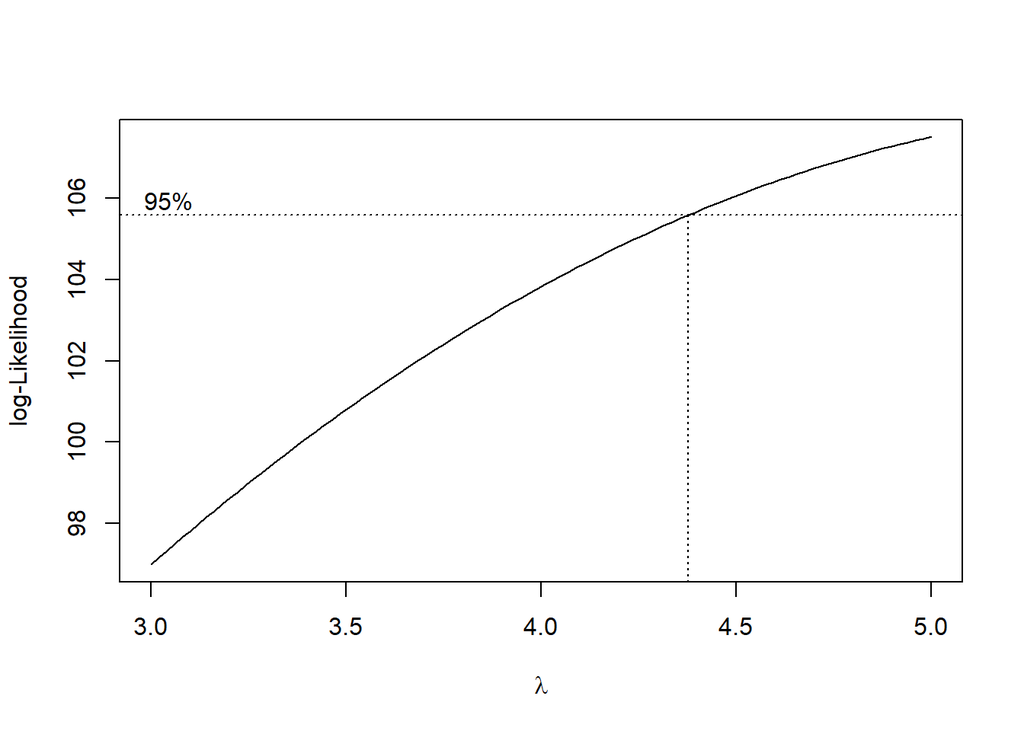

```r
#Nilai Rounded Lambda
lambda <- bc$x[which.max(bc$y)]
lambda
```

```
## [1] 5
```

```r
# Selang kepercayaan 95% untuk lambda
ci_lambda <- bc$x[bc$y > max(bc$y) - 0.5 * qchisq(0.95, 1)]

# Batas bawah dan batas atas
ci_lower <- min(ci_lambda)
ci_upper <- max(ci_lambda)

c(Batas_Bawah = ci_lower, Batas_Atas = ci_upper)
```

```
## Batas_Bawah  Batas_Atas
##    4.393939    5.000000
```

Hasil uji Box–Cox menunjukkan bahwa nilai λ optimum adalah 5 dengan interval kepercayaan 95% sebesar (4.394-5.000). Karena selang tersebut tidak memuat nilai λ = 1, maka dapat disimpulkan bahwa data **tidak stasioner dalam ragam** sehingga diperlukan penanganan.

### Differencing

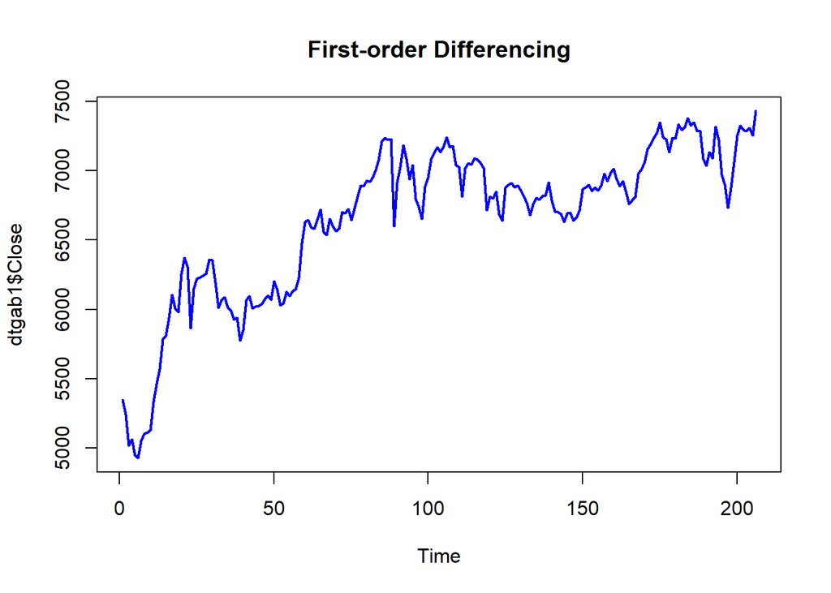

```r
diff1 <- diff(dtgab1$Close, differences = 1)

# Plot hasil differencing
ts.plot(dtgab1$Close,
        main = "First-order Differencing",
        col = "blue", lwd = 2)
```

#### Uji ADF Setelah Differencing

H0 : Data tidak stasioner dalam rataan

H1 : Data stasioner dalam rataan

```r
tseries::adf.test(diff1)
```

```
##
##  Augmented Dickey-Fuller Test
##
## data:  diff1
## Dickey-Fuller = -7.0151, Lag order = 5, p-value = 0.01
## alternative hypothesis: stationary
```

Berdasarkan uji ADF tersebut, didapat p-value < 0.01 yang lebih kecil dari taraf nyata 5% dan menandakan bahwa data hasil differencing pertama sudah **stasioner dalam rataan.**

#### Plot Box-Cox Setelah Differencing

```r
index <- 1:length(diff1)
bcc = boxcox(diff1 - min(diff1) + 1~index,
             lambda = seq(-1,5,by=1))
```

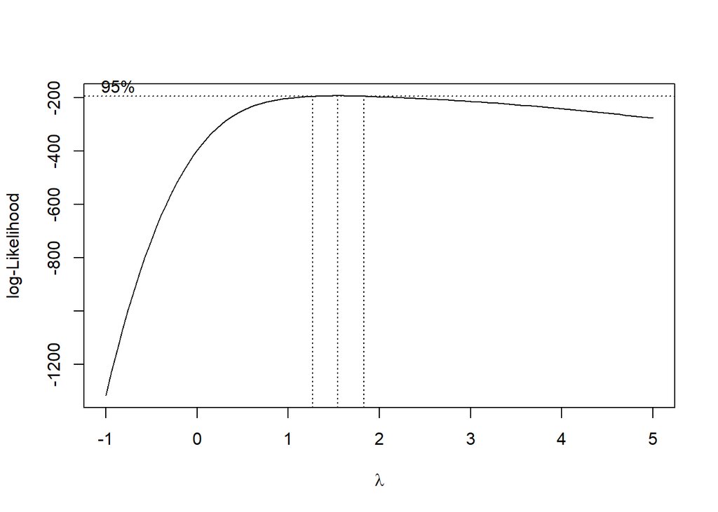

```r
#Nilai Rounded Lambda
lambdaa <- bcc$x[which.max(bcc$y)]
lambdaa
```

```
## [1] 1.545455
```

```r
# Selang kepercayaan 95% untuk lambda
ci_lambdaa <- bcc$x[bc$y > max(bcc$y) - 0.5 * qchisq(0.95, 1)]

# Batas bawah dan batas atas
ci_lowerr <- min(ci_lambdaa)
ci_upperr <- max(ci_lambdaa)

c(Batas_Bawah = ci_lowerr, Batas_Atas = ci_upperr)
```

```
## Batas_Bawah  Batas_Atas
##          -1           5
```

## Data Testing

```r
dtgab2 <- data1[207:258, ]
ts_test  <- ts(dtgab2$Close)
mean(dtgab2$Close)
```

```
## [1] 7152.213
```

```r
var(dtgab2$Close)
```

```
## [1] 190842
```

### Plot Time Series

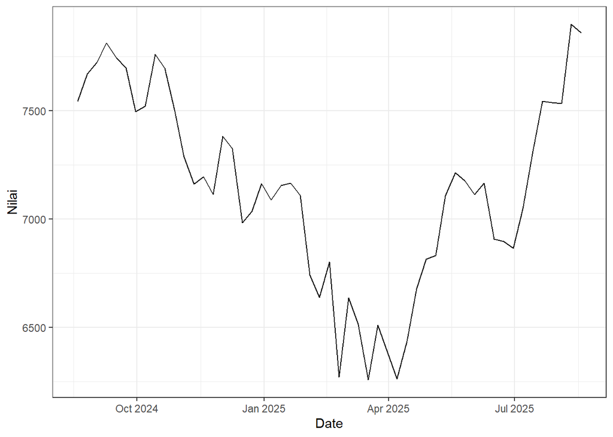

```r
plot1 <- dtgab2 |>
  ggplot(aes(x = Date, y = Close)) +
  geom_line() +
  theme_bw() +
  xlab("Date") +
  ylab("Nilai")

plot1
```

Berdasarkan plot time series tersebut, terlihat bahwa data testing **tidak stasioner dalam rataan dan ragam**, ditandai dengan adanya trend pada data serta perbedaan lebar pita pada plot.

### Plot ACF

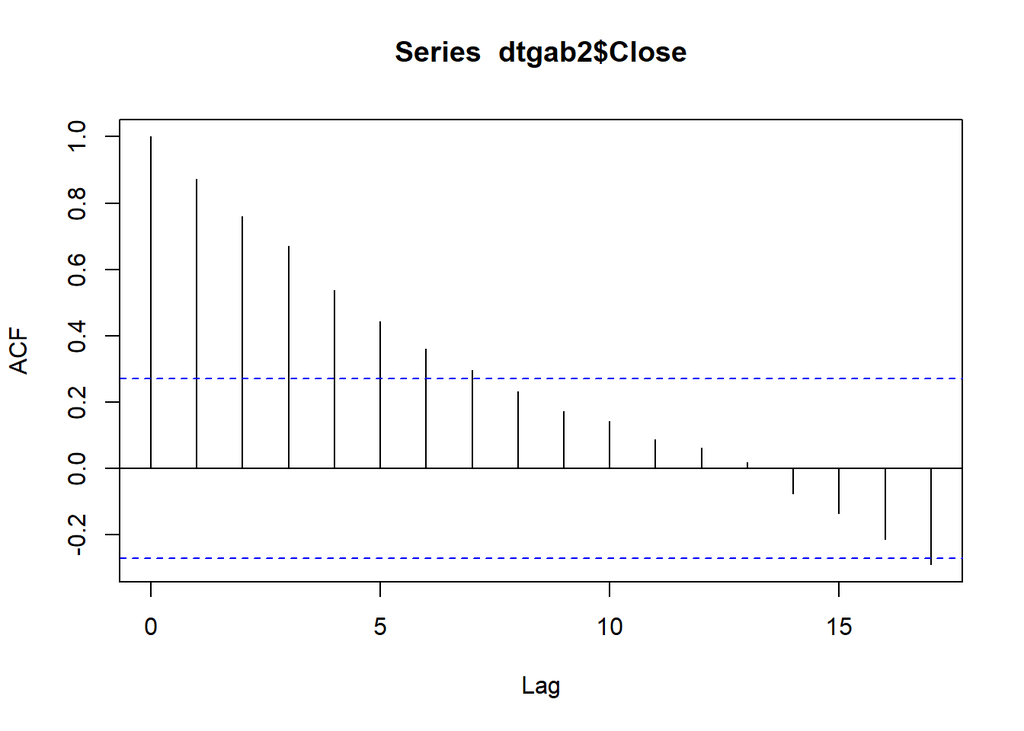

```r
acf(dtgab2$Close)
```

Berdasarkan plot ACF, terlihat bahwa plot ACF pada data testing menurun secara perlahan (tails off slowly) yang menandakan data **tidak stasioner dalam rataan.**

### Uji ADF

H0 : Data tidak stasioner dalam rataan

H1 : Data stasioner dalam rataan

```r
adf.test(dtgab2$Close)
```

```
##
##  Augmented Dickey-Fuller Test
##
## data:  dtgab2$Close
## Dickey-Fuller = -0.83293, Lag order = 3, p-value = 0.9532
## alternative hypothesis: stationary
```

Berdasarkan uji ADF tersebut, didapat p-value sebesar 0.9532 yang lebih besar dari taraf nyata 5% dan menandakan bahwa data **tidak stasioner dalam rataan**. Hal ini sesuai dengan hasil eksplorasi menggunakan plot time series dan plot ACF.

### Plot Box-Cox

```r
index <- 1:nrow(dtgab2)
bc2 = boxcox(dtgab2$Close+1~index,
             lambda = seq(3,5,by=1))
```

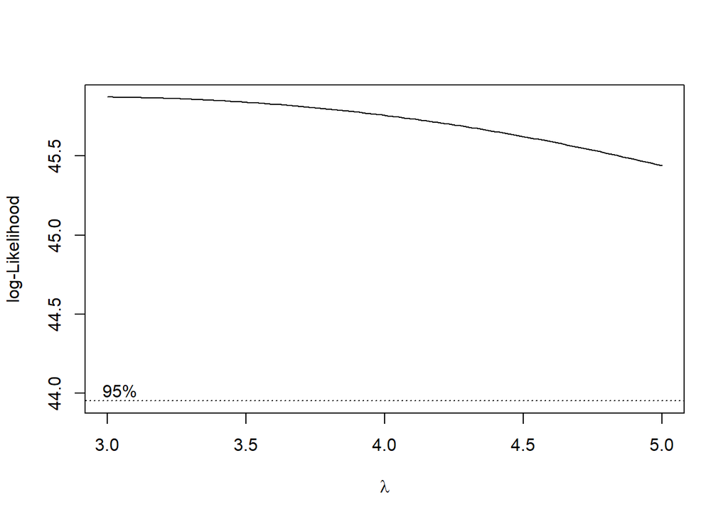

```r
#Nilai Rounded Lambda
lambda <- bc2$x[which.max(bc2$y)]
lambda
```

```
## [1] 3
```

```r
# Selang kepercayaan 95% untuk lambda
ci_lambda2 <- bc2$x[bc2$y > max(bc2$y) - 0.5 * qchisq(0.95, 1)]

# Batas bawah dan batas atas
ci_lower2 <- min(ci_lambda2)
ci_upper2 <- max(ci_lambda2)

c(Batas_Bawah = ci_lower2, Batas_Atas = ci_upper2)
```

```
## Batas_Bawah  Batas_Atas
##           3           5
```

Hasil uji Box–Cox menunjukkan bahwa nilai λ optimum adalah 3 dengan interval kepercayaan 95% sebesar (3-5). Karena selang tersebut tidak memuat nilai λ = 1, maka dapat disimpulkan bahwa data testing **tidak stasioner dalam ragam**. Hal ini sesuai dengan hasil eksplorasi menggunakan plot time series.

Zifa Aura Rahman  
G1401231010